# Spot the Problem

Module 2 · Day 1, Session 3: Naive Comparisons and Reading an RCT

3ie

## What this session gives you

By the end of this session you will be able to:

- Put Session 1’s question, **compared to what?**, to work on two comparisons that both look convincing
- Name the hidden problem in a **before-and-after** claim and in a **with-and-without** claim
- Explain, in plain terms, how **randomisation** removes the difference between the groups
- Read a randomised result: which number is the impact, and does it clear the decision rule

# 1 · Two comparisons, both convincing 18 min

## The GreenWaste programme

The **GreenWaste Program** helped businesses cut waste-management costs. A pilot ran, data was collected before and after, and now someone has to decide whether to take it national.

The bar it has to clear is fixed for the whole week at 1,000 AED.

Programme

GreenWaste, waste-cost reduction

Outcome

Waste-management costs (AED)

The decision

Scale up nationally, or not

The rule

Must cut costs by at least 1,000 AED

## Comparison A: before and after

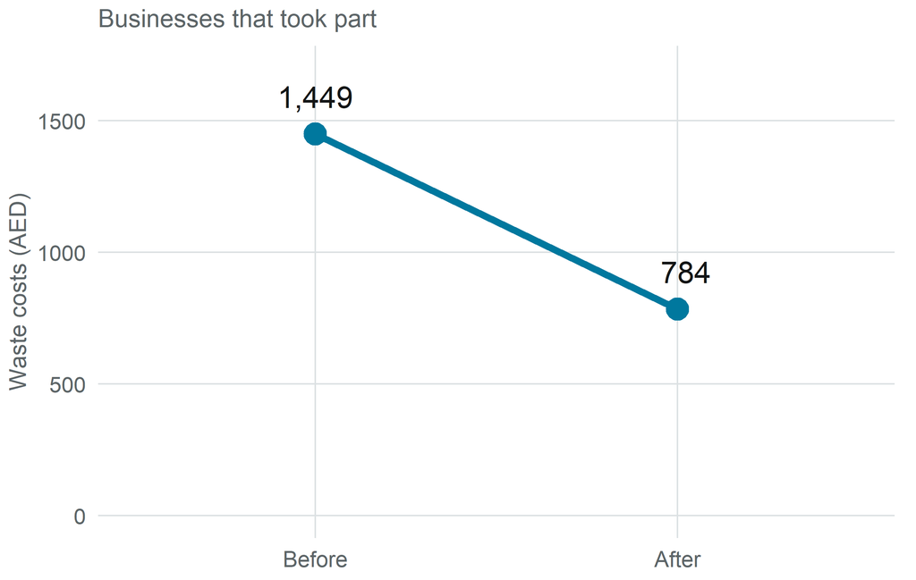

Businesses that took part paid **1,449 AED** before and **784 AED** after.

-665 AED

Fall in costs, before to after

The programme looks like it cut costs by 665 AED.

## Comparison B: with and without

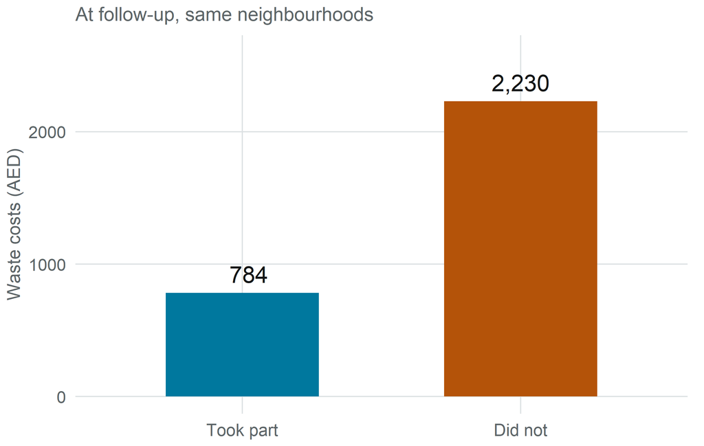

At the end, businesses that took part paid **784 AED**; those that did not paid **2,230 AED**.

-1,446 AED

Gap between the two groups

This comparison makes the programme look more than twice as good.

## `[MENTI PLACEHOLDER]` Which would you trust?

Both comparisons say GreenWaste worked. **Which would you trust more, and why?**

Before-and-after · With-and-without · Neither on its own

Live poll. Let the room commit before anything is revealed. Take two or three “why” answers out loud, do not correct them yet.

## `[MENTI PLACEHOLDER]` What might be wrong?

Open text, shown as a live word cloud: **in one phrase, what might be wrong with each of these comparisons?**

# 2 · The hidden problem in each 15 min

## Before-and-after compares to the past

A before-and-after number compares the programme to **what came before**, not to what would have happened anyway. Anything else that changed over the same period is included in that number.

Over these same two rounds, similar businesses that did **not** take part saw costs move from 2,079 to 2,230 AED on their own. Time was not standing still, so a plain before-and-after does not tell you what the programme alone did.

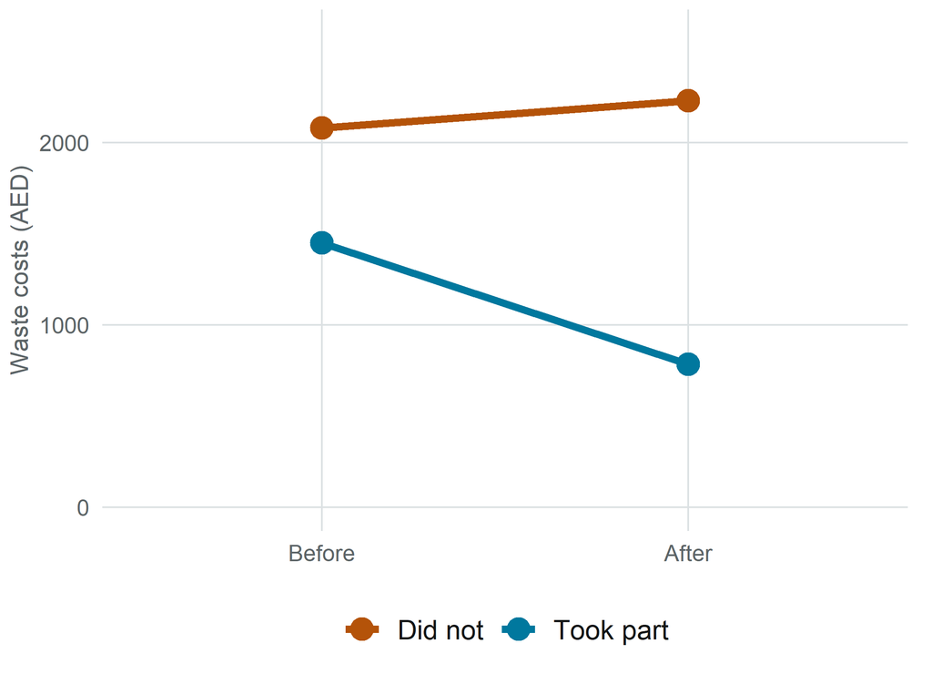

## With-and-without compares different groups

A with-and-without number compares people who took part to people who did not. But the two groups were **already different before the programme started**. The businesses that did not take part were not eligible: they were larger, less efficient, more costly to begin with.

So the -1,446 AED gap mixes two things together: any real effect of the programme, **and** the head start the eligible group already had. It overestimates the effect of the programme.

## Two biases, opposite directions

The truth is not halfway by coincidence. Each naive comparison is wrong for a different reason, and they are incorrect in **opposite directions**.

Before-and-after

Folds in other changes over time. Here it understates.

With-and-without

Compares groups that already differed. Here it overstates.

So

The honest answer sits between them, and neither comparison can find it.

## `.ask` On your desk

Think of an evaluation you have received. Was its headline a before-and-after number, or a with-and-without one? Which of these two problems could it have had?

Ninety seconds with your neighbour. Two or three examples to the room.

# Break 5 min

## Five-minute break

Back in five minutes. When we return: the one design that removes the difference between the groups.

# 3 · How randomisation fixes it 15 min

## Random draw

Both problems come from the same root: the group that took part and the group that did not were **not comparable**. Randomisation fixes it at the source. Decide who is offered the programme by **random draw**, not by who is eligible, keen, or easy to reach.

Same on average, even on what we cannot measure

## Why it works: two people versus two crowds

Pick **two people** at random from this room. They could differ in almost every way. Neither is a fair stand-in for the other.

Pick **two large groups** at random. On average they look alike: same mix of ages, sizes, experience, and the same mix of things you never measured. Any leftover difference is small and down to chance.

So when we compare two large randomly-formed groups, any real gap in the outcome is the programme, not some other factor that could give one group a head start over the other.

## `[MENTI PLACEHOLDER]` True or false?

1. Randomisation makes the two groups similar only on things we can measure.
2. With enough units, random assignment balances unmeasured things too.
3. A randomised comparison still needs the groups to have started out alike.

Live quiz, revealed one at a time. (1) False (2) True (3) It creates that, which is the point.

# 4 · Reading the randomised result 18 min

## First check: did the random draw work?

Check the two groups really did start out alike. A **balance table** compares them on their starting characteristics: read for whether the differences are small, with p-values that are **not** tiny.

```r
# Compare treated vs control neighbourhoods on each starting characteristic
df %>%
  filter(round == 0, eligible == 1) %>%
  select(treatment_neighborhood, age_manager, educ_manager,
         staff_size, foreign_owned, recycling_center_distance) %>%
  pivot_longer(-treatment_neighborhood) %>%
  group_by(name) %>%
  reframe(tidy(lm_robust(value ~ treatment_neighborhood))) %>%
  filter(term == "treatment_neighborhood")
```

| Characteristic | Treated | Control | Difference | p-value |
| --- | --- | --- | --- | --- |
| Manager age | 41.7 | 42.3 | -0.64 | 0.09 |
| Manager education | 3.0 | 2.8 | 0.16 | 0.02 |
| Foreign owned | 0.4 | 0.4 | 0.01 | 0.49 |
| Distance to recycling centre | 109.2 | 106.3 | 2.91 | 0.01 |
| Staff size | 5.8 | 5.7 | 0.06 | 0.26 |

## The estimate

```r
# Compare costs in treated vs control
# neighbourhoods at follow-up, among
# eligible businesses
lm_robust(
  waste_management_costs ~
    treatment_neighborhood,
  data = filter(df, round == 1,
                eligible == 1),
  clusters = neighborhood_identifier)
```

|  | Follow-up |
| --- | --- |
| Treated vs. control | −1014.078*** |
|  | (39.889) |
| Control group average | 1798.055*** |
|  | (30.912) |
| Num.Obs. | 5628 |
| R2 | 0.300 |

+ p < 0.1, * p < 0.05, ** p < 0.01, *** p < 0.001

## Which number is the impact?

**The impact** is the “Treated vs. control” row: about **-1,014 AED**. That is the whole result. Everything else is supporting detail.

**Not** the “control group average” (1,798): that is just where the comparison group sat, not an effect.

**Not** the stars on their own: they say the effect is unlikely to be zero, not that it is big enough to matter.

## Does it clear the rule?

-1,014 AED

Estimated cut in costs (95% CI: -1,093 to -935)

1,000The rule: cut by at least

1,014Estimated cut

YesClears the bar

## The picture

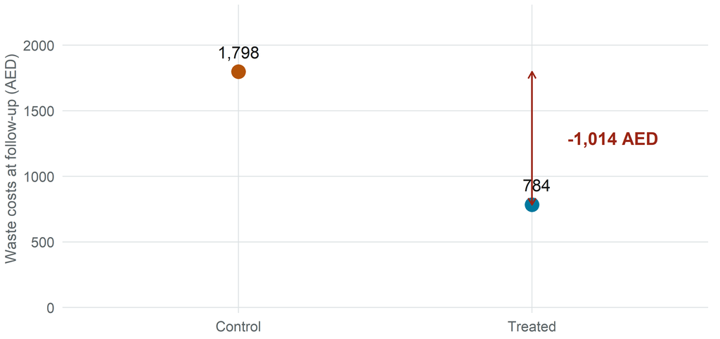

# 5 · AI Snapshot 18 min

## Asking AI to explain the pitfall

Suppose we ask AI: *“Explain in plain language why a before-and-after comparison can be misleading.”* Here is the kind of answer it might give. Some of what it says may be wrong.

A before-and-after comparison looks at the outcome before a programme and after it, and treats the difference as the programme’s effect. It can mislead because if the numbers changed, the programme is what changed them.

The fix is simple: as long as you measure the same group before and after, a before-and-after comparison gives you the true effect. To be safe, you can also run a statistical test, and if the change is significant then the programme worked.

In this case costs fell, so we can conclude the programme caused the full fall of 665 AED.

In your groups, mark anything that looks wrong. Three minutes.

## What might be wrong here

**1 · It assumed away the whole problem.** “If the numbers changed, the programme changed them” ignores everything else that moved over the same period.

**2 · It called before-and-after a true-effect method.** It is exactly the comparison we just showed is biased. There is no comparison group in it.

**3 · It confused significant with correct.** A significant before-and-after change is still a biased number. Significance does not repair the design.

**4 · It quoted the 665 as the causal effect.** That is the naive figure. The fair estimate is about 1,014 AED, and the model had no way to know that.

## Fluent, confident, and wrong

Notice: nothing in the tone flags the invented parts. No hedge, no hesitation.

The wrong sentences read exactly like the right ones. In a briefing note you would not be able to tell them apart. Fluency is not accuracy, and confidence is not a signal.

## The same question, a better prompt

### What people type

*“Explain why a before-and-after comparison can be misleading.”*

- No context about the case
- No decision rule
- No invitation to say what it is unsure of

### What to type instead

*I am a commissioner, not an analyst. A programme’s costs fell from 1,449 to 784 AED after it ran, before-and-after, with no comparison group. Our decision rule: it must cut costs by at least 1,000 AED to justify scale-up.*

*Before you answer, ask me any questions you need about what else changed over the same period and who was in each group.*

*Then explain, in plain language: what this before-and-after number can and cannot tell me, and what comparison I would need to trust it.*

## Your turn

In your groups:

1. Run the **short prompt**. Read what you get.
2. Run the **full prompt card**. Answer the questions it asks you.
3. Compare: what did the second answer add, remove, or hedge?
4. Paste the second answer into a **fresh chat** and ask: *“Review this for errors and overstatement.”*

Step 4 matters: a clean second conversation catches what the first is already committed to.

## Debrief

- What did AI **overstate**?
- What did it **soften** or leave out?
- Did it **invent** anything: a test, a number, a caveat?

Two habits, every time: tell the AI your decision rule, and make it ask you questions before it answers.

# 6 · The real case: Abu Dhabi Police 15 min

Programme

Design

Randomised (drew lots)

Outcome

Decision rule

Using the printed output, in your groups:

1. **Balance:** did the two groups start out alike? Where do you look?
2. **The estimate:** which single number is the impact? Which numbers are not?
3. **The rule:** does the estimate, and its confidence interval, clear the bar?

## `.ask` Group interpretation

Each group reports back: does this evaluation clear the bar, and how confident are you? What would change your mind?

Two minutes per group. Look for groups that quote the intercept, or that read the stars as the whole answer: those are today’s traps in the wild.

# 7 · Close 6 min

## Three questions to ask the evaluator

Take these back to your desk. For any headline number:

1

Compared to what? Is this before-and-after, with-and-without, or a fair comparison?

2

If the groups were not randomised, how do you know they started out alike?

3

Does the effect, and its confidence interval, clear our decision rule, not just zero?

## Key takeaways

- Before-and-after folds in everything else that changed. It can understate.
- With-and-without compares groups that already differed. It can overstate.
- Randomisation makes the groups alike on average, even on what we cannot measure.
- Read for the one number that is the impact, and judge it against the rule, not zero.